# *Stock Market Clustering*

## Live Stock Market Data Analysis From Yahoo Finance (K-Means Clustering)

#### In this project, we will be extracting live Stock Market data from Yahoo Finance, find similarities amongst various companies using their stock market prices and then group them into different clusters using K-Means algorithm (Unsupervised Learning algorithm).

#### pandas-datareader will be used to create a DataFrame from the Yahoo Finance website.

#### yfinance will be also used to to an API problem currently with pandas-datereader

```python
#! pip install pandas-datareader
#! pip install yfinance --upgrade --no-cache-dir
```

```python
from pandas_datareader import data as pdr
import yfinance as yf
yf.pdr_override()
import pandas as pd
import numpy as np
import datetime
import matplotlib.pyplot as plt
pd.options.display.max_columns = 30
#import warnings
#warnings.simplefilter('ignore')
```

```python
companies_dict = {'Amazon': 'AMZN',
                  'Apple': 'AAPL',
                  'Walgreens': 'WBA',
                  'Northrop Grumman': 'NOC',
                  'Boeing': 'BA',
                  'Lockheed Martin': 'LMT',
                  'McDonalds': 'MCD',
                  'Intel': 'INTC',
                  'IBM': 'IBM',
                  'Texas Instruments': 'TXN',
                  'MasterCard': 'MA',
                  'Visa': 'V',
                  'Microsoft': 'MSFT',
                  'General Electrics': 'GE',
                  'American Express': 'AXP',
                  'Pepsi': 'PEP',
                  'Coca-Cola': 'KO',
                  'Johnson & Johnson': 'JNJ',
                  'Toyoya': 'TM', 'Honda': 'HMC',
                  'Sony': 'SONY',
                  'Exxon': 'XOM',
                  'Chevron': 'CVX',
                  'Ford': 'F',
                  'Bank of America': 'BAC',
                  'JP Morgan Chase': 'JPM',
                  'HP': 'HPQ',
                  'Facebook': 'FB',
                  'Twitter': 'TWTR',
                  'Alphabet': 'GOOGL'}
names = list(companies_dict.keys())
codes = list(companies_dict.values())
```

```python
data_source = 'yahoo'
start_date = str(datetime.date.today() - datetime.timedelta(days=365*5))
end_date = str(datetime.date.today())
print(f"Start Date: {start_date}")
print(f"End Date: {end_date}")
```

```
Start Date: 2016-07-27
End Date: 2021-07-26
```

```python
df = pdr.get_data_yahoo(list(companies_dict.values()), start=start_date, end=end_date)
df
```

```
[*********************100%***********************]  30 of 30 completed
```

| Date | Adj Close AAPL | Adj Close AMZN | Adj Close AXP | Adj Close BA | Adj Close BAC | Adj Close CVX | Adj Close F | Adj Close FB | Adj Close GE | Adj Close GOOGL | Adj Close HMC | Adj Close HPQ | Adj Close IBM | Adj Close INTC | Adj Close JNJ | ... | Volume JPM | Volume KO | Volume LMT | Volume MA | Volume MCD | Volume MSFT | Volume NOC | Volume PEP | Volume SONY | Volume TM | Volume TWTR | Volume TXN | Volume V | … |
| --- | --- | --- | --- | --- | --- | --- | --- | --- | --- | --- | --- | --- | --- | --- | --- | --- | --- | --- | --- | --- | --- | --- | --- | --- | --- | --- | --- | --- | --- | --- |
| 2016-07-27 | 24.043583 | 736.669983 | 59.814663 | 124.065628 | 13.233034 | 82.196663 | 11.135532 | 123.339996 | 27.572309 | 761.969971 | 27.139999 | 12.001522 | 129.576981 | 30.606861 | 109.231033 | ... | 11806800 | 37461100 | 2593300 | 5696800 | 9939200 | 32327500 | 1423500 | 4724200 | 743100 | 384800 | 83161900 | 13973400 | 10194400 | … |
| 2016-07-28 | 24.368214 | 752.609985 | 59.999882 | 121.373680 | 13.278264 | 81.818871 | 10.226344 | 125.000000 | 27.545866 | 765.840027 | 26.990000 | 11.958628 | 129.208633 | 30.554138 | 108.959663 | ... | 10013400 | 13077800 | 2716000 | 5209400 | 6239400 | 37550400 | 1219200 | 3446500 | 1465000 | 600000 | 31442400 | 9143200 | 8709700 | … |
| 2016-07-29 | 24.337851 | 758.809998 | 59.694275 | 121.966843 | 13.106404 | 82.373528 | 10.186113 | 123.940002 | 27.448904 | 791.340027 | 27.120001 | 12.018682 | 128.608139 | 30.633228 | 109.633766 | ... | 13210400 | 16530500 | 2178300 | 4364100 | 7460900 | 30558700 | 769400 | 3995300 | 3656400 | 756500 | 26057200 | 7963100 | 7777700 | … |
| 2016-08-01 | 24.767578 | 767.739990 | 59.388668 | 121.556206 | 12.961682 | 79.664703 | 10.041287 | 124.309998 | 27.457720 | 800.940002 | 27.290001 | 12.164517 | 129.272690 | 30.624441 | 109.782578 | ... | 11422600 | 12349700 | 2782400 | 3512100 | 4208800 | 26003400 | 1199100 | 3880700 | 1797000 | 445100 | 26053200 | 5983000 | 8908800 | … |
| 2016-08-02 | 24.400913 | 760.580017 | 58.777466 | 120.087067 | 12.780781 | 80.050514 | 9.606809 | 123.089996 | 27.369574 | 800.119995 | 28.049999 | 12.061572 | 128.576111 | 30.369606 | 109.301079 | ... | 13550000 | 12825200 | 4770800 | 3948600 | 4504200 | 35122000 | 1062900 | 3431600 | 1130900 | 534100 | 16611300 | 6391300 | 7910000 | … |
| ... | ... | ... | ... | ... | ... | ... | ... | ... | ... | ... | ... | ... | ... | ... | ... | ... | ... | ... | ... | ... | ... | ... | ... | ... | ... | ... | ... | ... | ... | … |
| 2021-07-19 | 142.449997 | 3549.590088 | 162.809998 | 206.990005 | 36.930000 | 95.959999 | 13.280000 | 336.950012 | 12.000000 | 2491.560059 | 31.070000 | 27.590000 | 137.919998 | 54.639999 | 166.880005 | ... | 22172900 | 19527000 | 1357600 | 6814400 | 3774900 | 32935600 | 866700 | 5750200 | 712400 | 261100 | 15830100 | 4181300 | 11474600 | … |
| 2021-07-20 | 146.149994 | 3573.189941 | 168.869995 | 217.149994 | 37.689999 | 96.529999 | 13.910000 | 341.660004 | 12.700000 | 2524.189941 | 31.520000 | 28.209999 | 139.970001 | 55.240002 | 168.449997 | ... | 15385200 | 16257900 | 1268000 | 3542200 | 3275600 | 26259700 | 911300 | 5213500 | 554000 | 152000 | 11583900 | 4287300 | 7072300 | … |
| 2021-07-21 | 145.399994 | 3585.199951 | 172.509995 | 222.539993 | 38.459999 | 99.820000 | 14.190000 | 346.230011 | 13.080000 | 2550.979980 | 31.670000 | 28.520000 | 141.300003 | 56.230000 | 169.490005 | ... | 12356700 | 20918200 | 922800 | 2393100 | 2146600 | 24364300 | 632500 | 4905900 | 419500 | 183200 | 10082900 | 6352800 | 11241400 | … |
| 2021-07-22 | 146.800003 | 3638.030029 | 170.899994 | 220.869995 | 37.959999 | 98.820000 | 13.910000 | 351.190002 | 12.700000 | 2568.429932 | 31.309999 | 27.799999 | 140.710007 | 55.959999 | 169.979996 | ... | 9913300 | 13402700 | 688400 | 4180300 | 2538300 | 23384100 | 549500 | 3333500 | 348900 | 321200 | 24130400 | 12673900 | 10293600 | … |
| 2021-07-23 | 148.559998 | 3656.639893 | 173.179993 | 221.520004 | 37.700001 | 98.860001 | 13.820000 | 369.790009 | 12.710000 | 2660.300049 | 31.440001 | 28.200001 | 141.339996 | 53.000000 | 171.789993 | ... | 9661700 | 12143100 | 795900 | 3719800 | 3995100 | 22753500 | 478400 | 3588400 | 485700 | 195900 | 44218500 | 5981100 | 6762000 | … |

1257 rows × 180 columns

```python
df.isna().sum().sort_values(ascending=False)[:15]
```

```
Adj Close  AAPL    0
Low        SONY    0
           TWTR    0
           TXN     0
           V       0
           WBA     0
           XOM     0
Open       AAPL    0
           AMZN    0
           AXP     0
           BA      0
           BAC     0
           CVX     0
           F       0
           FB      0
dtype: int64
```

#### movements is the difference of closing and opening prices of a particular day. Positive movement implies buying the stock while negative movement implies selling.

```python
stock_open = df['Open'].T
stock_close = df['Close'].T
movements = stock_close - stock_open
```

```python
print(f"{'='*65}\n{'*'*15} stock_open {'*'*15}\n{stock_open.iloc[:3,:5]}\n{'='*65}")
print(f"{'='*65}\n{'*'*15} stock_close {'*'*15}\n{stock_close.iloc[:3,:5]}\n{'='*65}")
print(f"{'='*65}\n{'*'*15} movements {'*'*15}\n{movements.iloc[:3,:5]}\n{'='*65}")
```

```
=================================================================
*************** stock_open ***************
Date  2016-07-27  2016-07-28  2016-07-29  2016-08-01  2016-08-02
AAPL   26.067499   25.707500   26.047501   26.102501   26.512501
AMZN  737.969971  745.979980  765.000000  759.869995  763.809998
AXP    64.269997   64.360001   64.699997   64.489998   63.959999
=================================================================
=================================================================
*************** stock_close ***************
Date  2016-07-27  2016-07-28  2016-07-29  2016-08-01  2016-08-02
AAPL   25.737499   26.084999   26.052500   26.512501   26.120001
AMZN  736.669983  752.609985  758.809998  767.739990  760.580017
AXP    64.589996   64.790001   64.459999   64.129997   63.470001
=================================================================
=================================================================
*************** movements ***************
Date  2016-07-27  2016-07-28  2016-07-29  2016-08-01  2016-08-02
AAPL   -0.330000    0.377499    0.004999    0.410000   -0.392500
AMZN   -1.299988    6.630005   -6.190002    7.869995   -3.229980
AXP     0.320000    0.430000   -0.239998   -0.360001   -0.489998
=================================================================
```

#### sum_of_movements is the sum of differences of closing and opening prices for all days.

```python
sum_of_movements = np.sum(movements, axis=1)
```

```python
for i in range(len(companies_dict)):
    print(f"{'='*30}\nCompany: {df['High'].columns[i]}\nSum of Movements(5 Years):\n{sum_of_movements[i]}\n{'='*30}")
```

```
==============================
Company: AAPL
Sum of Movements(5 Years):
55.34481239318848
==============================
==============================
Company: AMZN
Sum of Movements(5 Years):
-843.2141723632812
==============================
==============================
Company: AXP
Sum of Movements(5 Years):
16.770206451416016
==============================
==============================
Company: BA
Sum of Movements(5 Years):
-189.9903793334961
==============================
==============================
Company: BAC
Sum of Movements(5 Years):
5.869987487792969
==============================
==============================
Company: CVX
Sum of Movements(5 Years):
-65.4798355102539
==============================
==============================
Company: F
Sum of Movements(5 Years):
-12.000017166137695
==============================
==============================
Company: FB
Sum of Movements(5 Years):
126.07007598876953
==============================
```

[output cut: 95 more lines]

```
==============================
Company: V
Sum of Movements(5 Years):
-1.1900711059570312
==============================
==============================
Company: WBA
Sum of Movements(5 Years):
-34.16001892089844
==============================
==============================
Company: XOM
Sum of Movements(5 Years):
-53.20004653930664
==============================
```

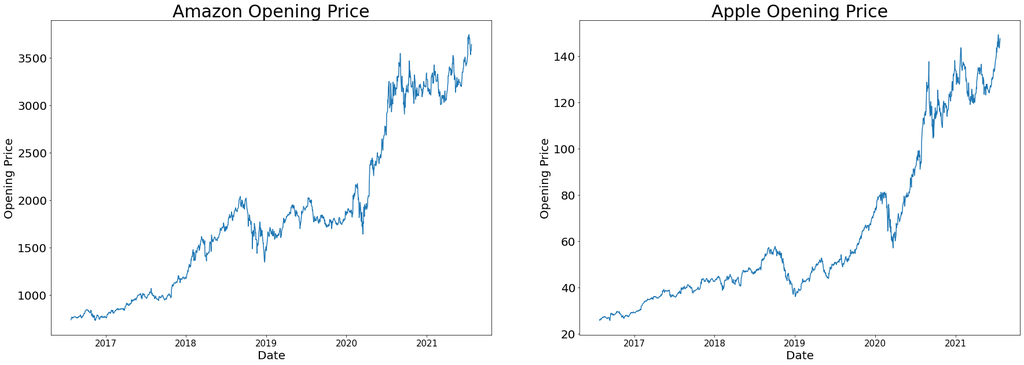

```python
fig = plt.figure(figsize=(30,10))
fig.add_subplot(1,2,1)
plt.plot(df['Open']['AMZN'])
plt.title('Amazon Opening Price', fontsize=30)
plt.xticks(fontsize=15)
plt.yticks(fontsize=20)
plt.xlabel('Date', fontsize=20)
plt.ylabel('Opening Price', fontsize=20)

fig.add_subplot(1,2,2)
plt.plot(df['Open']['AAPL'])
plt.title('Apple Opening Price', fontsize=30)
plt.xticks(fontsize=15)
plt.yticks(fontsize=20)
plt.xlabel('Date', fontsize=20)
plt.ylabel('Opening Price', fontsize=20)

plt.show()
```

# Plotting Opening/Closing Prices for Each Stock (5 Years)

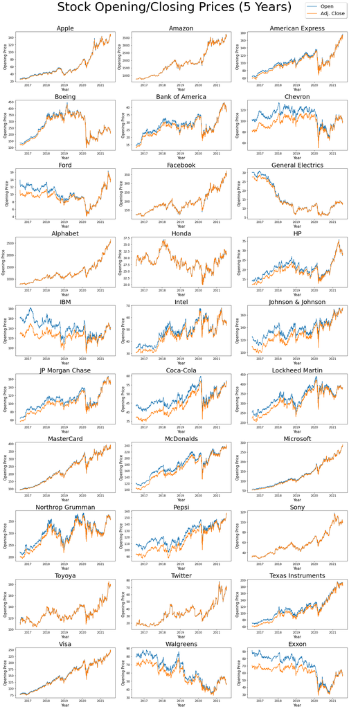

```python
fig, ax = plt.subplots(10,3,figsize=(20,40))
i = 0
for x in range(10):
    for y in range(3):
        ax[x,y].plot(df['Open'].iloc[:,i])
        ax[x,y].plot(df['Adj Close'].iloc[:,i])
        loc = codes.index(df['Open'].columns[i])
        ax[x,y].set_title(f'{names[loc]}', fontsize=25)
        ax[x,y].tick_params(axis='both', labelsize=12)
        ax[x,y].set_xlabel('Year', fontsize=15)
        ax[x,y].set_ylabel('Opening Price', fontsize=15)
        i +=1
fig.suptitle('Stock Opening/Closing Prices (5 Years)', fontsize=50, x=0.5, y=1.01)
plt.tight_layout()
fig.legend(['Open', 'Adj. Close'], fontsize=20, shadow=True, loc='upper right')
plt.show()
```

# Plotting Stock Movement For the Last 30 Days

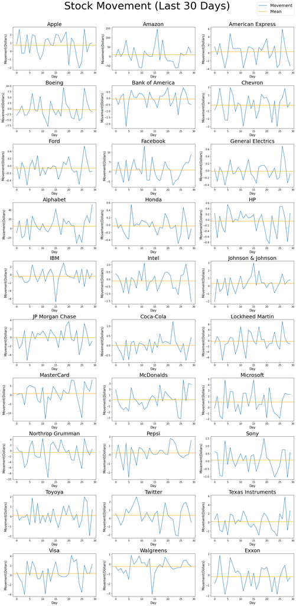

```python
fig, ax = plt.subplots(10,3,figsize=(20,40))
i = 0
for x in range(10):
    for y in range(3):
        ax[x,y].plot(movements.loc[movements.index[i]][-30:].reset_index(drop=True))
        ax[x,y].axhline(movements.loc[movements.index[i]][-30:].reset_index(drop=True).mean(), color='orange')
        loc = codes.index(df['Open'].columns[i])
        ax[x,y].set_title(f'{names[loc]}', fontsize=25)
        ax[x,y].tick_params(axis='both', labelsize=12)
        ax[x,y].set_xlabel('Day', fontsize=15)
        ax[x,y].set_ylabel('Movement(Dollars)', fontsize=15)
        i +=1
fig.legend(['Movement', 'Mean'],fontsize=20, loc='upper right')
fig.suptitle('Stock Movement (Last 30 Days)', fontsize=50, x=0.5, y=1.01)
plt.tight_layout()
plt.show()
```

#### A positive movement is desirable because it suggests the price has increased during the day.

# Plotting Each Stock's Volume Over 5 Years

### Volume refers to the total number of shares that are actually traded (bought and sold) during the trading day or specified set period of time. If only five transactions occur in a day, the volume for that day is set at five.

### While the same shares may be traded back and forth multiple times, the volume is counted on each transaction. Therefore if 500 shares of XYZ were bought, then sold, then re-bought and then re-sold again resulting in four tickets, then the volume would register as 2,000 shares, even though the same 500 shares may have been in play multiple times.

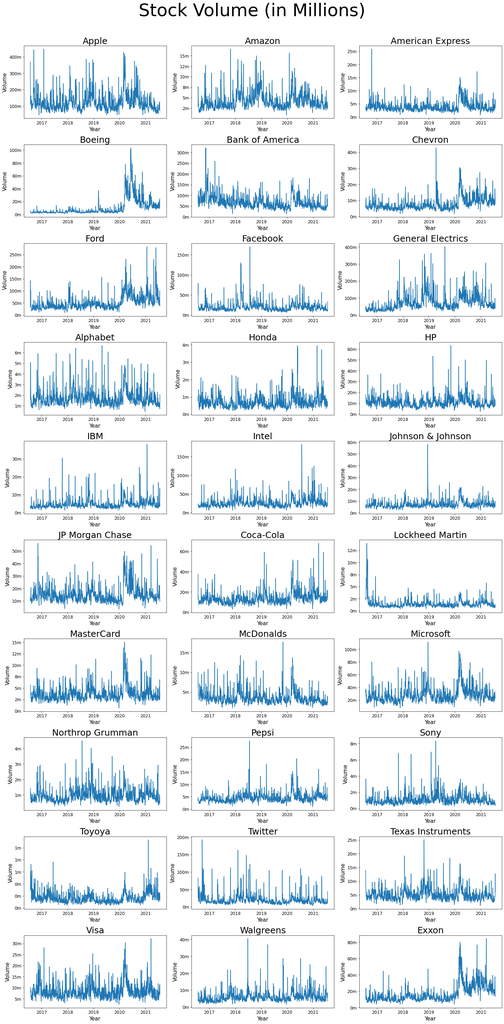

```python
import matplotlib.ticker as mticker
fig, ax = plt.subplots(10,3,figsize=(20,40))
i = 0
for x in range(10):
    for y in range(3):
        ax[x,y].plot(df['Volume'].iloc[:,i])
        loc = codes.index(df['Open'].columns[i])
        ax[x,y].set_title(f'{names[loc]}', fontsize=25)
        ax[x,y].tick_params(axis='both', labelsize=12)
        ax[x,y].ticklabel_format(axis='y',style='plain')
        ax[x,y].set_xlabel('Year', fontsize=15)
        ax[x,y].set_ylabel('Volume', fontsize=15)
        ticks_loc = ax[x,y].get_yticks()
        ax[x,y].yaxis.set_major_locator(mticker.FixedLocator(ticks_loc))
        ax[x,y].set_yticklabels(['{:,.0f}'.format(x) + 'm' for x in ticks_loc / 1000000])
        i +=1
fig.suptitle('Stock Volume (in Millions)', fontsize=50, x=0.5, y=1.01)
plt.tight_layout()
plt.show()
```

#### The peaks suggest there are high volumes of stocks traded on certain days. This may be due to several situations which might affect the image of the company positively or negatively.

# Normalization

### Stock prices of Amazon and Apple have different scales. There is a significant difference in the rate of change of units in stock price, and in that case we need to normalize our data in order to have consistency for further analysis.

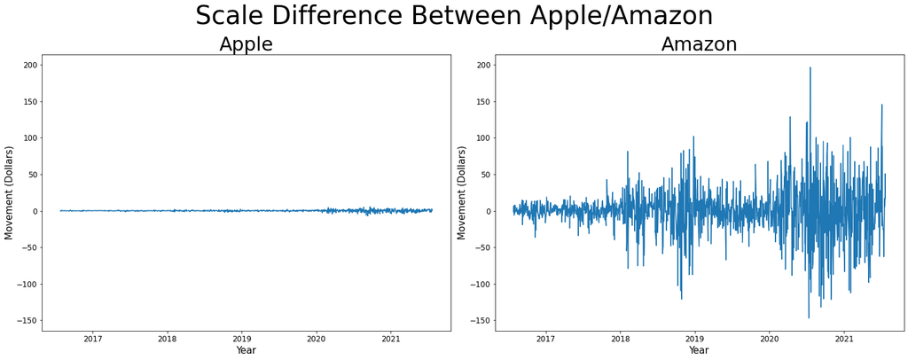

```python
fig = plt.figure(figsize=(20,8))
ax = fig.add_subplot(121)
ax.plot(movements.loc['AAPL'])
ax.set_title('Apple', fontsize=30)
ax.tick_params(labelsize=12)
ax.set_xlabel('Year', fontsize=15)
ax.set_ylabel('Movement (Dollars)', fontsize=15)
ax2 = fig.add_subplot(122, sharey=ax)
ax2.plot(movements.loc['AMZN'])
ax2.set_title('Amazon', fontsize=30)
ax2.tick_params(labelsize=12)
ax2.set_xlabel('Year', fontsize=15)
ax2.set_ylabel('Movement (Dollars)', fontsize=15)
fig.suptitle('Scale Difference Between Apple/Amazon', fontsize=40)
plt.tight_layout()
plt.show()
```

## Normalizer(): Normalizes each sample (row) using that row's L2 norm by default.

[figure not shown]

### example below:

```python
x = np.array([[4, 1, 2, 2], [1, 3, 9, 3], [5, 7, 5, 1]])
print(f"Original Array:\n{x}")
print(f"Square Each Value:\n{x**2}")
print(f"Sum Each Vector(Row):\n{np.sum(x**2, axis=1)}")
print(f"Square Root of Each Sum(L2 Norm):\n{np.sqrt(np.sum(x**2, axis=1))}")
print(f"Normalize by Dividing Each Vector(Row) With Its L2 Norm:")
for i in range(3):
    print(x[i] / np.sqrt(np.sum(x**2, axis=1))[i])
```

```
Original Array:
[[4 1 2 2]
 [1 3 9 3]
 [5 7 5 1]]
Square Each Value:
[[16  1  4  4]
 [ 1  9 81  9]
 [25 49 25  1]]
Sum Each Vector(Row):
[ 25 100 100]
Square Root of Each Sum(L2 Norm):
[ 5. 10. 10.]
Normalize by Dividing Each Vector(Row) With Its L2 Norm:
[0.8 0.2 0.4 0.4]
[0.1 0.3 0.9 0.3]
[0.5 0.7 0.5 0.1]
```

## Measures of Center/Spread for Normalizer

```python
from sklearn.preprocessing import Normalizer
normalizer = Normalizer()
norm_movements = pd.DataFrame(normalizer.fit_transform(movements), columns=movements.columns, index=movements.index)
norm_movements.T.describe()[1:]
```

|  | AAPL | AMZN | AXP | BA | BAC | CVX | F | FB | GE | GOOGL | HMC | HPQ | IBM | INTC | JNJ | JPM | KO | LMT | MA | MCD | MSFT | NOC | PEP | SONY | TM | TWTR | TXN | V | WBA | … |
| --- | --- | --- | --- | --- | --- | --- | --- | --- | --- | --- | --- | --- | --- | --- | --- | --- | --- | --- | --- | --- | --- | --- | --- | --- | --- | --- | --- | --- | --- | --- |
| mean | 0.001123 | -0.000591 | 0.000259 | -0.000881 | 0.000326 | -0.001077 | -0.001717 | 0.000914 | -0.002320 | 0.001275 | -0.001169 | 0.000882 | -0.000578 | 0.000556 | -0.000040 | 0.000327 | -0.000473 | -0.000772 | -0.000107 | 0.000169 | 0.000877 | -0.000393 | 0.000395 | -0.000511 | -0.000981 | 0.000501 | 0.000741 | -0.000014 | -0.000834 | … |
| std | 0.028194 | 0.028210 | 0.028215 | 0.028203 | 0.028215 | 0.028196 | 0.028164 | 0.028202 | 0.028121 | 0.028188 | 0.028192 | 0.028203 | 0.028211 | 0.028211 | 0.028217 | 0.028215 | 0.028213 | 0.028206 | 0.028216 | 0.028216 | 0.028203 | 0.028214 | 0.028214 | 0.028212 | 0.028200 | 0.028212 | 0.028207 | 0.028217 | 0.028204 | … |
| min | -0.175265 | -0.129463 | -0.135908 | -0.197650 | -0.154892 | -0.230826 | -0.116905 | -0.150878 | -0.143326 | -0.129410 | -0.159351 | -0.171886 | -0.148677 | -0.160505 | -0.228660 | -0.113656 | -0.216731 | -0.161536 | -0.191267 | -0.197738 | -0.173462 | -0.154840 | -0.307035 | -0.182761 | -0.228050 | -0.150007 | -0.133925 | -0.178143 | -0.130116 | … |
| 25% | -0.007590 | -0.010907 | -0.011245 | -0.012998 | -0.013257 | -0.015926 | -0.016187 | -0.011935 | -0.018031 | -0.011562 | -0.015376 | -0.011625 | -0.015016 | -0.012020 | -0.011897 | -0.013177 | -0.012469 | -0.012746 | -0.009408 | -0.012823 | -0.009709 | -0.012819 | -0.011801 | -0.011868 | -0.014209 | -0.011016 | -0.013275 | -0.010642 | -0.016264 | … |
| 50% | 0.001276 | -0.000079 | 0.000969 | -0.000583 | 0.000698 | -0.001034 | -0.001799 | 0.000456 | -0.002312 | 0.001166 | -0.001398 | 0.001661 | -0.000371 | 0.001061 | 0.000605 | 0.001030 | 0.000594 | -0.000128 | 0.001011 | 0.000291 | 0.001159 | 0.001073 | 0.001073 | 0.000475 | -0.000347 | 0.000648 | 0.001008 | 0.001166 | 0.000000 | … |
| 75% | 0.010587 | 0.010054 | 0.012408 | 0.010900 | 0.014652 | 0.014685 | 0.012590 | 0.013849 | 0.012714 | 0.015111 | 0.013978 | 0.015777 | 0.014275 | 0.013434 | 0.014115 | 0.014207 | 0.013063 | 0.011337 | 0.011196 | 0.012823 | 0.011448 | 0.013135 | 0.012873 | 0.011868 | 0.012823 | 0.012960 | 0.014955 | 0.012100 | 0.015344 | … |
| max | 0.141335 | 0.173110 | 0.204348 | 0.167516 | 0.137449 | 0.125754 | 0.151078 | 0.181400 | 0.195339 | 0.121381 | 0.164943 | 0.200118 | 0.132178 | 0.218131 | 0.162118 | 0.163071 | 0.179322 | 0.233722 | 0.164443 | 0.208375 | 0.164188 | 0.195571 | 0.236445 | 0.170894 | 0.192698 | 0.152923 | 0.175430 | 0.141261 | 0.167862 | … |

## Measures of Center/Spread for StandardScaler (for comparison)

```python
from sklearn.preprocessing import StandardScaler
pd.DataFrame(StandardScaler().fit_transform(movements.T), columns=movements.T.columns, index=movements.T.index).describe().apply(lambda s: s.apply('{0:.6f}'.format))[1:]
```

|  | AAPL | AMZN | AXP | BA | BAC | CVX | F | FB | GE | GOOGL | HMC | HPQ | IBM | INTC | JNJ | JPM | KO | LMT | MA | MCD | MSFT | NOC | PEP | SONY | TM | TWTR | TXN | V | WBA | … |
| --- | --- | --- | --- | --- | --- | --- | --- | --- | --- | --- | --- | --- | --- | --- | --- | --- | --- | --- | --- | --- | --- | --- | --- | --- | --- | --- | --- | --- | --- | --- |
| mean | 0.000000 | -0.000000 | -0.000000 | 0.000000 | 0.000000 | 0.000000 | 0.000000 | 0.000000 | 0.000000 | -0.000000 | 0.000000 | 0.000000 | -0.000000 | -0.000000 | 0.000000 | 0.000000 | -0.000000 | 0.000000 | 0.000000 | 0.000000 | -0.000000 | -0.000000 | 0.000000 | 0.000000 | 0.000000 | 0.000000 | -0.000000 | 0.000000 | 0.000000 | … |
| std | 1.000398 | 1.000398 | 1.000398 | 1.000398 | 1.000398 | 1.000398 | 1.000398 | 1.000398 | 1.000398 | 1.000398 | 1.000398 | 1.000398 | 1.000398 | 1.000398 | 1.000398 | 1.000398 | 1.000398 | 1.000398 | 1.000398 | 1.000398 | 1.000398 | 1.000398 | 1.000398 | 1.000398 | 1.000398 | 1.000398 | 1.000398 | 1.000398 | 1.000398 | … |
| min | -6.258678 | -4.570072 | -4.827899 | -6.979686 | -5.503498 | -8.151490 | -4.091496 | -5.384476 | -5.016256 | -4.638087 | -5.613058 | -6.128328 | -5.251832 | -5.711404 | -8.105526 | -4.041432 | -7.668325 | -5.701908 | -6.777463 | -7.016771 | -6.184045 | -5.476335 | -10.900759 | -6.462606 | -8.055415 | -5.336998 | -4.776099 | -6.315429 | -4.585601 | … |
| 25% | -0.309158 | -0.365854 | -0.407869 | -0.429805 | -0.481585 | -0.526831 | -0.513973 | -0.455795 | -0.558942 | -0.455595 | -0.504143 | -0.443641 | -0.511999 | -0.445977 | -0.420360 | -0.478820 | -0.425387 | -0.424688 | -0.329743 | -0.460648 | -0.375499 | -0.440609 | -0.432448 | -0.402720 | -0.469294 | -0.408389 | -0.497078 | -0.376810 | -0.547316 | … |
| 50% | 0.005404 | 0.018133 | 0.025201 | 0.010573 | 0.013191 | 0.001539 | -0.002898 | -0.016254 | 0.000277 | -0.003866 | -0.008120 | 0.027628 | 0.007340 | 0.017886 | 0.022874 | 0.024912 | 0.037827 | 0.022836 | 0.039642 | 0.004330 | 0.010024 | 0.051987 | 0.024018 | 0.034939 | 0.022494 | 0.005201 | 0.009490 | 0.041838 | 0.029581 | … |
| 75% | 0.335809 | 0.377460 | 0.430770 | 0.417873 | 0.507963 | 0.559257 | 0.508176 | 0.458839 | 0.534831 | 0.491050 | 0.537486 | 0.528346 | 0.526689 | 0.456669 | 0.501866 | 0.492140 | 0.479980 | 0.429483 | 0.400758 | 0.448631 | 0.374985 | 0.479662 | 0.442443 | 0.438931 | 0.489707 | 0.441769 | 0.504141 | 0.429469 | 0.573824 | … |
| max | 4.975030 | 6.159778 | 7.236112 | 5.973285 | 4.861926 | 4.500005 | 5.427278 | 6.402343 | 7.031664 | 4.262616 | 5.894412 | 7.067214 | 4.707735 | 7.715437 | 5.749212 | 5.770359 | 6.375382 | 8.316907 | 5.834042 | 7.381912 | 5.792867 | 6.948399 | 8.369768 | 6.077991 | 6.870890 | 5.404846 | 6.195598 | 5.008776 | 5.983604 | … |

## Measures of Center/Spread for MinMaxScaler (for comparison)

```python
from sklearn.preprocessing import MinMaxScaler
pd.DataFrame(MinMaxScaler().fit_transform(movements.T), columns=movements.T.columns, index=movements.T.index).describe()[1:]
```

|  | AAPL | AMZN | AXP | BA | BAC | CVX | F | FB | GE | GOOGL | HMC | HPQ | IBM | INTC | JNJ | JPM | KO | LMT | MA | MCD | MSFT | NOC | PEP | SONY | TM | TWTR | TXN | V | WBA | … |
| --- | --- | --- | --- | --- | --- | --- | --- | --- | --- | --- | --- | --- | --- | --- | --- | --- | --- | --- | --- | --- | --- | --- | --- | --- | --- | --- | --- | --- | --- | --- |
| mean | 0.557134 | 0.425921 | 0.400190 | 0.538848 | 0.530948 | 0.644310 | 0.429834 | 0.456822 | 0.416359 | 0.521092 | 0.487775 | 0.464424 | 0.527315 | 0.425372 | 0.585036 | 0.411895 | 0.546033 | 0.406733 | 0.537403 | 0.487320 | 0.516331 | 0.440761 | 0.565670 | 0.515335 | 0.539679 | 0.496842 | 0.435311 | 0.557693 | 0.433864 | … |
| std | 0.089053 | 0.093235 | 0.082924 | 0.077233 | 0.096513 | 0.079074 | 0.105097 | 0.084874 | 0.083035 | 0.112395 | 0.086935 | 0.075813 | 0.100446 | 0.074507 | 0.072206 | 0.101959 | 0.071235 | 0.071361 | 0.079324 | 0.069478 | 0.083527 | 0.080517 | 0.051913 | 0.079773 | 0.067022 | 0.093131 | 0.091180 | 0.088342 | 0.094652 | … |
| min | 0.000000 | 0.000000 | 0.000000 | 0.000000 | 0.000000 | 0.000000 | 0.000000 | 0.000000 | 0.000000 | 0.000000 | 0.000000 | 0.000000 | 0.000000 | 0.000000 | 0.000000 | 0.000000 | 0.000000 | 0.000000 | 0.000000 | 0.000000 | 0.000000 | 0.000000 | 0.000000 | 0.000000 | 0.000000 | 0.000000 | 0.000000 | 0.000000 | 0.000000 | … |
| 25% | 0.529613 | 0.391825 | 0.366381 | 0.505666 | 0.484487 | 0.602669 | 0.375839 | 0.418152 | 0.369965 | 0.469906 | 0.443965 | 0.430804 | 0.475907 | 0.392157 | 0.554696 | 0.363095 | 0.515743 | 0.376438 | 0.511257 | 0.455328 | 0.484979 | 0.405298 | 0.543229 | 0.483221 | 0.508238 | 0.458823 | 0.390005 | 0.524418 | 0.382080 | … |
| 50% | 0.557615 | 0.427611 | 0.402279 | 0.539665 | 0.532220 | 0.644432 | 0.429530 | 0.455443 | 0.416382 | 0.520658 | 0.487069 | 0.466518 | 0.528052 | 0.426704 | 0.586687 | 0.414434 | 0.548726 | 0.408361 | 0.540547 | 0.487621 | 0.517167 | 0.444945 | 0.566916 | 0.518121 | 0.541186 | 0.497326 | 0.436176 | 0.561388 | 0.436663 | … |
| 75% | 0.587027 | 0.461100 | 0.435897 | 0.571109 | 0.579953 | 0.688515 | 0.483221 | 0.495750 | 0.460751 | 0.576262 | 0.534483 | 0.504464 | 0.580198 | 0.459384 | 0.621260 | 0.462053 | 0.580210 | 0.437369 | 0.569180 | 0.518478 | 0.547640 | 0.479366 | 0.588630 | 0.550336 | 0.572487 | 0.537968 | 0.481260 | 0.595618 | 0.488156 | … |
| max | 1.000000 | 1.000000 | 1.000000 | 1.000000 | 1.000000 | 1.000000 | 1.000000 | 1.000000 | 1.000000 | 1.000000 | 1.000000 | 1.000000 | 1.000000 | 1.000000 | 1.000000 | 1.000000 | 1.000000 | 1.000000 | 1.000000 | 1.000000 | 1.000000 | 1.000000 | 1.000000 | 1.000000 | 1.000000 | 1.000000 | 1.000000 | 1.000000 | 1.000000 | … |

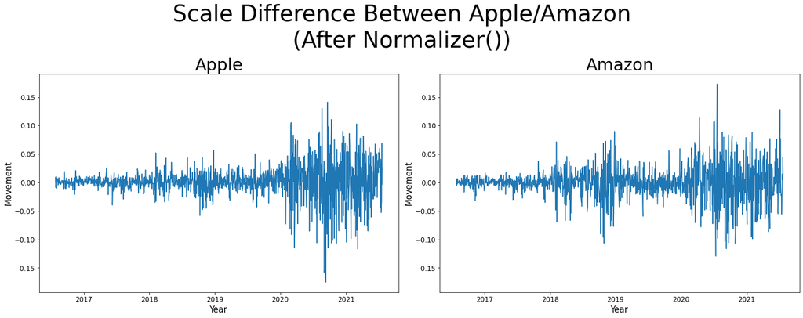

```python
fig = plt.figure(figsize=(20,8))
ax = fig.add_subplot(121)
ax.plot(norm_movements.loc['AAPL'])
ax.set_title('Apple', fontsize=30)
ax.tick_params(labelsize=12)
ax.set_xlabel('Year', fontsize=15)
ax.set_ylabel('Movement', fontsize=15)
ax2 = fig.add_subplot(122, sharey=ax)
ax2.plot(norm_movements.loc['AMZN'])
ax2.set_title('Amazon', fontsize=30)
ax2.tick_params(labelsize=12)
ax2.set_xlabel('Year', fontsize=15)
ax2.set_ylabel('Movement', fontsize=15)
fig.suptitle('Scale Difference Between Apple/Amazon\n(After Normalizer())', fontsize=40)
plt.tight_layout()
plt.show()
```

#### Now we have normalized movements for Amazon and Apple.

# KMeans Classifier: Finding the k value

```python
from sklearn.cluster import KMeans
sum_of_squared_distances = []
for i in range(1,16):
    kmeans = KMeans(n_clusters=i, max_iter=1000, random_state=1)
    kmeans = kmeans.fit(norm_movements)
    sum_of_squared_distances.append(kmeans.inertia_)
```

```python
# Sum of Squared Distances
```

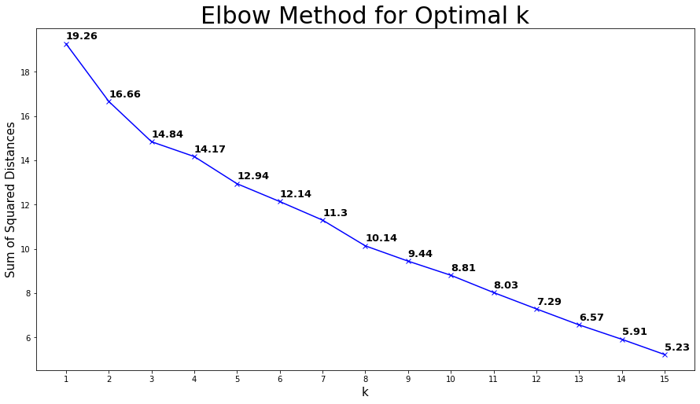

```python
plt.figure(figsize=(15,8))
plt.plot(np.arange(1,16), sum_of_squared_distances, 'bx-')
plt.xlabel('k', fontsize=15)
plt.ylabel('Sum of Squared Distances', fontsize=15)
plt.title('Elbow Method for Optimal k', fontsize=30)
plt.xticks(np.arange(1,16))
for i in range(15):
    plt.text(i+1, sum_of_squared_distances[i]+0.2, np.round(sum_of_squared_distances[i], 2), fontdict={'fontsize':13, 'fontweight': 'bold'})
plt.show()
```

# Creating a Pipeline

```python
from sklearn.pipeline import make_pipeline
from sklearn.cluster import KMeans

# Initialize a normalizer
normalizer = Normalizer()

# Create KMeans model
kmeans = KMeans(n_clusters=5, max_iter=1000, random_state=1)

# Make a pipeline combining our normalizer and KMeans model
pipeline = make_pipeline(normalizer, kmeans)

# Fit pipeline to daily stock movements created earlier
pipeline.fit(movements)
predictions = pipeline.predict(movements)
predictions
```

```
array([0, 0, 3, 3, 3, 3, 3, 0, 2, 0, 2, 2, 2, 0, 4, 3, 4, 1, 0, 0, 0, 1,
       4, 0, 2, 0, 0, 0, 2, 3])
```

# Creating a DataFrame of the Resultant Clusters

```python
clusters = pd.DataFrame({'Code': movements.index, 'Cluster': predictions})
clusters = clusters.merge(pd.DataFrame({'Company': companies_dict.keys(), 'Code': companies_dict.values()}), on='Code').set_index('Code')
clusters = clusters[['Company', 'Cluster']].sort_values(by='Cluster')
clusters
```

| Code | Company | Cluster |
| --- | --- | --- |
| AAPL | Apple | 0 |
| MSFT | Microsoft | 0 |
| INTC | Intel | 0 |
| MA | MasterCard | 0 |
| FB | Facebook | 0 |
| SONY | Sony | 0 |
| GOOGL | Alphabet | 0 |
| TWTR | Twitter | 0 |
| TXN | Texas Instruments | 0 |
| V | Visa | 0 |
| AMZN | Amazon | 0 |
| MCD | McDonalds | 0 |
| NOC | Northrop Grumman | 1 |
| LMT | Lockheed Martin | 1 |
| GE | General Electrics | 2 |
| HMC | Honda | 2 |
| HPQ | HP | 2 |
| IBM | IBM | 2 |
| WBA | Walgreens | 2 |
| TM | Toyoya | 2 |
| XOM | Exxon | 3 |
| JPM | JP Morgan Chase | 3 |
| F | Ford | 3 |
| CVX | Chevron | 3 |
| BAC | Bank of America | 3 |
| BA | Boeing | 3 |
| AXP | American Express | 3 |
| PEP | Pepsi | 4 |
| KO | Coca-Cola | 4 |
| JNJ | Johnson & Johnson | 4 |

# Dimensionality Reduction: Principal Component Analysis(PCA)

```python
from sklearn.decomposition import PCA

normalizer = Normalizer()
pca = PCA(n_components=2)
kmeans = KMeans(n_clusters=5, max_iter=1000, random_state=1)

pipeline = make_pipeline(normalizer, pca, kmeans)
pipeline.fit(movements)
predictions = pipeline.predict(movements)
predictions
```

```
array([4, 4, 3, 0, 3, 3, 3, 4, 3, 4, 0, 0, 0, 1, 2, 3, 2, 2, 1, 0, 4, 2,
       2, 1, 0, 4, 1, 1, 0, 3])
```

```python
clusters_pca = pd.DataFrame({'Code': movements.index, 'Cluster': predictions})
clusters_pca = clusters_pca.merge(pd.DataFrame({'Company': companies_dict.keys(), 'Code': companies_dict.values()}), on='Code').set_index('Code')
clusters_pca = clusters_pca[['Company', 'Cluster']].sort_values(by='Cluster')
clusters_pca
```

| Code | Company | Cluster |
| --- | --- | --- |
| MCD | McDonalds | 0 |
| BA | Boeing | 0 |
| TM | Toyoya | 0 |
| WBA | Walgreens | 0 |
| IBM | IBM | 0 |
| HMC | Honda | 0 |
| HPQ | HP | 0 |
| V | Visa | 1 |
| TXN | Texas Instruments | 1 |
| SONY | Sony | 1 |
| INTC | Intel | 1 |
| MA | MasterCard | 1 |
| JNJ | Johnson & Johnson | 2 |
| NOC | Northrop Grumman | 2 |
| PEP | Pepsi | 2 |
| LMT | Lockheed Martin | 2 |
| KO | Coca-Cola | 2 |
| XOM | Exxon | 3 |
| GE | General Electrics | 3 |
| F | Ford | 3 |
| CVX | Chevron | 3 |
| BAC | Bank of America | 3 |
| AXP | American Express | 3 |
| JPM | JP Morgan Chase | 3 |
| GOOGL | Alphabet | 4 |
| MSFT | Microsoft | 4 |
| FB | Facebook | 4 |
| TWTR | Twitter | 4 |
| AMZN | Amazon | 4 |
| AAPL | Apple | 4 |

# Plotting the Decision Boundary

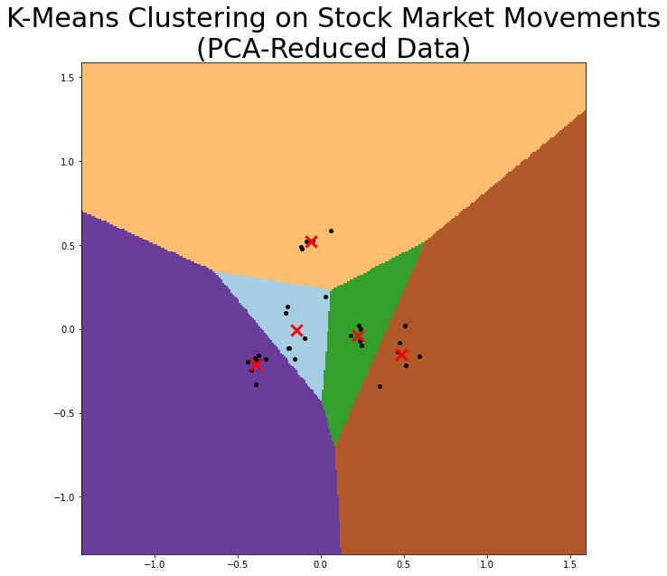

```python
pca = PCA(n_components=2)
pca_data = pca.fit_transform(norm_movements)
# Define step size of mesh
h = 0.01
# Plot the decision boundary
x_min, x_max = pca_data[:,0].min() - 1, pca_data[:,0].max() + 1
y_min, y_max = pca_data[:,1].min() - 1, pca_data[:,1].max() + 1
xx, yy, = np.meshgrid(np.arange(x_min, x_max, h), np.arange(y_min, y_max, h))
# Obtain labels for each point in the mesh using our trained model
kpredictions = kmeans.predict(np.c_[xx.ravel(), yy.ravel()])
# Put the result into a color plot
kpredictions = kpredictions.reshape(xx.shape)
# Define color plot
cmap = plt.cm.Paired
# Plotting figure
plt.clf()
plt.figure(figsize=(10,10))
plt.imshow(kpredictions, interpolation='nearest', extent=(xx.min(), xx.max(), yy.min(), yy.max()), cmap=cmap, aspect='auto', origin='lower')
plt.plot(pca_data[:,0], pca_data[:,1], 'k.', markersize=8)
# Plot the centroid of each cluster as a white X
centroids = kmeans.cluster_centers_
plt.scatter(centroids[:,0], centroids[:,1], marker='x', s=150, linewidths=3, color='r', zorder=10)
plt.title('K-Means Clustering on Stock Market Movements\n(PCA-Reduced Data)', fontsize=30)
plt.xlim(x_min, x_max)
plt.ylim(y_min, y_max)
plt.show()
```

## Further detail on the above visualization and the process behind it.

```python
print(f"x_min (pca_data[:,0].min() - 1): {x_min}")
print(f"This will be the left-most limit for the x-axis.\n-1 or +1 is used to provide more space in the figure in every case.\n{'-'*75}")
print(f"x_max (pca_data[:,0].max() + 1): {x_max}")
print(f"This will be the right-most limit for the x-axis.\n{'-'*75}")
print(f"y_min (pca_data[:,1].min() - 1): {y_min}")
print(f"This will be the down-most limit for the y-axis.\n{'-'*75}")
print(f"y_max (pca_data[:,1].max() + 1): {y_max}")
print(f"This will be the up-most limit for the y-axis.\n{'-'*75}")
print(f"np.arange(x_min, x_max, h):\n{np.arange(x_min, x_max, h)}\nShape: {np.arange(x_min, x_max, h).shape}")
print(f"These will be the x-coordinates with step size 0.01 for the mesh grid.\n{'-'*75}")
print(f"np.arange(y_min, y_max, h):\n{np.arange(y_min, y_max, h)}\nShape: {np.arange(y_min, y_max, h).shape}")
print(f"These will be the y-coordinates with step size 0.01 for the mesh grid.\n{'-'*75}")
print(f"{'='*75}\n{'*'*25} Results of Mesh Grid: {'*'*25}\n{'='*75}")
print(f"xx:\n{xx}\nShape: {xx.shape}")
print(f"From left to right on our figure, these will be the x-coordinates that will be used to create a color-map.\n{'-'*75}")
print(f"yy:\n{yy}\nShape: {yy.shape}")
print(f"From left to right on our figure, these will be the y-coordinates that will be used to create a color-map.")
print(f"The reason they repeat across each row is because the y value will not change as we move horizontally in the figure.\n{'-'*75}")
print(f"xx.ravel():\n{xx.ravel()}\nShape: {xx.ravel().shape}")
print(f"This reshapes xx into a 1D array.\n{'-'*75}")
print(f"yy.ravel():\n{yy.ravel()}\nShape: {yy.ravel().shape}")
print(f"This reshapes yy into a 1D array.\nNow both xx and yy will have the same shape, and will be concatenated.\n{'-'*75}")
print(f"np.c_[xx.ravel(), yy.ravel()]:\n{np.c_[xx.ravel(), yy.ravel()]}\nShape: {np.c_[xx.ravel(), yy.ravel()].shape}")
print(f"This 2D array is a combination of every point in our figure from the x-min/x-max to the y-min/y-max.")
print(f"All of these x/y combinations will be passed into our KMeans algorithm to make a prediction as to which cluster they belong to.")
print(f"We will utilize this to create a figure where each one of these points is color-coded with respect to the cluster they belong to.\n{'-'*75}")
print(f"kmeans.predict(np.c_[xx.ravel(), yy.ravel()]):\n{kmeans.predict(np.c_[xx.ravel(), yy.ravel()])}\nShape: {kmeans.predict(np.c_[xx.ravel(), yy.ravel()]).shape}")
print(f"These are the predictions for every combination of x/y coordinates.\n{'-'*75}")
```

```
x_min (pca_data[:,0].min() - 1): -1.4388524605985176
This will be the left-most limit for the x-axis.
-1 or +1 is used to provide more space in the figure in every case.
---------------------------------------------------------------------------
x_max (pca_data[:,0].max() + 1): 1.5965709394990164
This will be the right-most limit for the x-axis.
---------------------------------------------------------------------------
y_min (pca_data[:,1].min() - 1): -1.3410702734121012
This will be the down-most limit for the y-axis.
---------------------------------------------------------------------------
y_max (pca_data[:,1].max() + 1): 1.5875295148997282
This will be the up-most limit for the y-axis.
---------------------------------------------------------------------------
np.arange(x_min, x_max, h):
[-1.43885246e+00 -1.42885246e+00 -1.41885246e+00 -1.40885246e+00
 -1.39885246e+00 -1.38885246e+00 -1.37885246e+00 -1.36885246e+00
 -1.35885246e+00 -1.34885246e+00 -1.33885246e+00 -1.32885246e+00
 -1.31885246e+00 -1.30885246e+00 -1.29885246e+00 -1.28885246e+00
 -1.27885246e+00 -1.26885246e+00 -1.25885246e+00 -1.24885246e+00
 -1.23885246e+00 -1.22885246e+00 -1.21885246e+00 -1.20885246e+00
 -1.19885246e+00 -1.18885246e+00 -1.17885246e+00 -1.16885246e+00
 -1.15885246e+00 -1.14885246e+00 -1.13885246e+00 -1.12885246e+00
 -1.11885246e+00 -1.10885246e+00 -1.09885246e+00 -1.08885246e+00
 -1.07885246e+00 -1.06885246e+00 -1.05885246e+00 -1.04885246e+00
 -1.03885246e+00 -1.02885246e+00 -1.01885246e+00 -1.00885246e+00
 -9.98852461e-01 -9.88852461e-01 -9.78852461e-01 -9.68852461e-01
 -9.58852461e-01 -9.48852461e-01 -9.38852461e-01 -9.28852461e-01
 -9.18852461e-01 -9.08852461e-01 -8.98852461e-01 -8.88852461e-01
 -8.78852461e-01 -8.68852461e-01 -8.58852461e-01 -8.48852461e-01
 -8.38852461e-01 -8.28852461e-01 -8.18852461e-01 -8.08852461e-01
 -7.98852461e-01 -7.88852461e-01 -7.78852461e-01 -7.68852461e-01
 -7.58852461e-01 -7.48852461e-01 -7.38852461e-01 -7.28852461e-01
 -7.18852461e-01 -7.08852461e-01 -6.98852461e-01 -6.88852461e-01
 -6.78852461e-01 -6.68852461e-01 -6.58852461e-01 -6.48852461e-01
 -6.38852461e-01 -6.28852461e-01 -6.18852461e-01 -6.08852461e-01
 -5.98852461e-01 -5.88852461e-01 -5.78852461e-01 -5.68852461e-01
 -5.58852461e-01 -5.48852461e-01 -5.38852461e-01 -5.28852461e-01
 -5.18852461e-01 -5.08852461e-01 -4.98852461e-01 -4.88852461e-01
 -4.78852461e-01 -4.68852461e-01 -4.58852461e-01 -4.48852461e-01
 -4.38852461e-01 -4.28852461e-01 -4.18852461e-01 -4.08852461e-01
```

[output cut: 185 more lines]

```
 [-1.41885246 -1.34107027]
 ...
 [ 1.57114754  1.57892973]
 [ 1.58114754  1.57892973]
 [ 1.59114754  1.57892973]]
Shape: (89072, 2)
This 2D array is a combination of every point in our figure from the x-min/x-max to the y-min/y-max.
All of these x/y combinations will be passed into our KMeans algorithm to make a prediction as to which cluster they belong to.
We will utilize this to create a figure where each one of these points is color-coded with respect to the cluster they belong to.
---------------------------------------------------------------------------
kmeans.predict(np.c_[xx.ravel(), yy.ravel()]):
[3 3 3 ... 2 2 2]
Shape: (89072,)
These are the predictions for every combination of x/y coordinates.
---------------------------------------------------------------------------
```

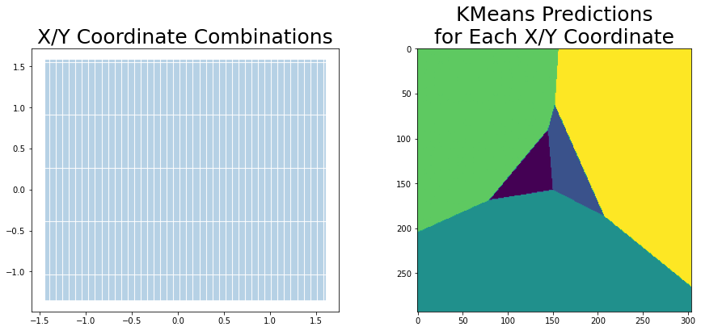

```python
fig, ax = plt.subplots(1,2, figsize=(15,6))
ax[0].scatter(xx,yy, s=0.01)
ax[0].set_title('X/Y Coordinate Combinations', fontsize=25)
ax[1].imshow(kpredictions)
ax[1].set_title('KMeans Predictions\nfor Each X/Y Coordinate', fontsize=25)
plt.show()
```